# DEM 7283 - Ordinal & Multinomial Logit Models

Corey S. Sparks, PhD

21 February, 2022

# Ordinal and Multinomial Logit Specifications

This example will cover the use of R functions for fitting Ordinal and Multinomial logit models to complex survey data.

For this example I am using 2020 CDC Behavioral Risk Factor Surveillance System (BRFSS) SMART MSA data. [Link](https://www.cdc.gov/brfss/smart/smart_2020.html)

# Other logit model specifications

In the basic logistic regression model, we assumed a dichotomous outcome * y = 0 or 1 This is a very flexible type of model since we can write any number of outcomes as a dichotomous variable.

Although the logistic regression model is very flexible, we may often run into other kinds of outcomes that it is not applicable to

- E.g. A multiple choice outcome: A behavioral decision to migrate to a set of several possible new residences.
- E.g. An ordered outcome with ranked levels: Liberal to conservative: Very liberal, somewhat liberal, somewhat conservative, very conservative

These types of outcomes require other kinds of regression models to analyze them.

## Logit model for ordinal outcomes

Suppose we have an outcome with *J* ordered outcomes, and each person, i, has a response: $Y_{i}$, and we can write the probability of a person having response level *J* as: $Pr(Y_ij = j)$ for J= 1 … J

For an ordered response it is easier to work with the *cumulative probability function* or

$Pr(Y_ij \leqslant j)$

So the probabilities increase in adjacent categories (ordered categories). I.e.
$$Pr(Y_ij
\leqslant 3)>Pr(Y_ij \leqslant 2)>Pr(Y_ij \leqslant 1)$$
Since we are using cumulative probabilities, we do not actually have to estimate all *J* probabilities. We need only estimate *J-1* probabilities, due to the complementary rule of probability:
$$Pr(y=0) =
1-Pr(y>0)$$

In order to construct a regression model, we have to link a linear function of covariates to these probabilities. A general depiction of this model can be thought of as a **latent trait model**, where a latent variable, *z* is not observable but continuous, but we can observe the discrete representation of it as the *J* categories, then we can write this as:

$$\pi_{j-1} < Z{i} \leqslant
\pi{j}$$
or graphically as:

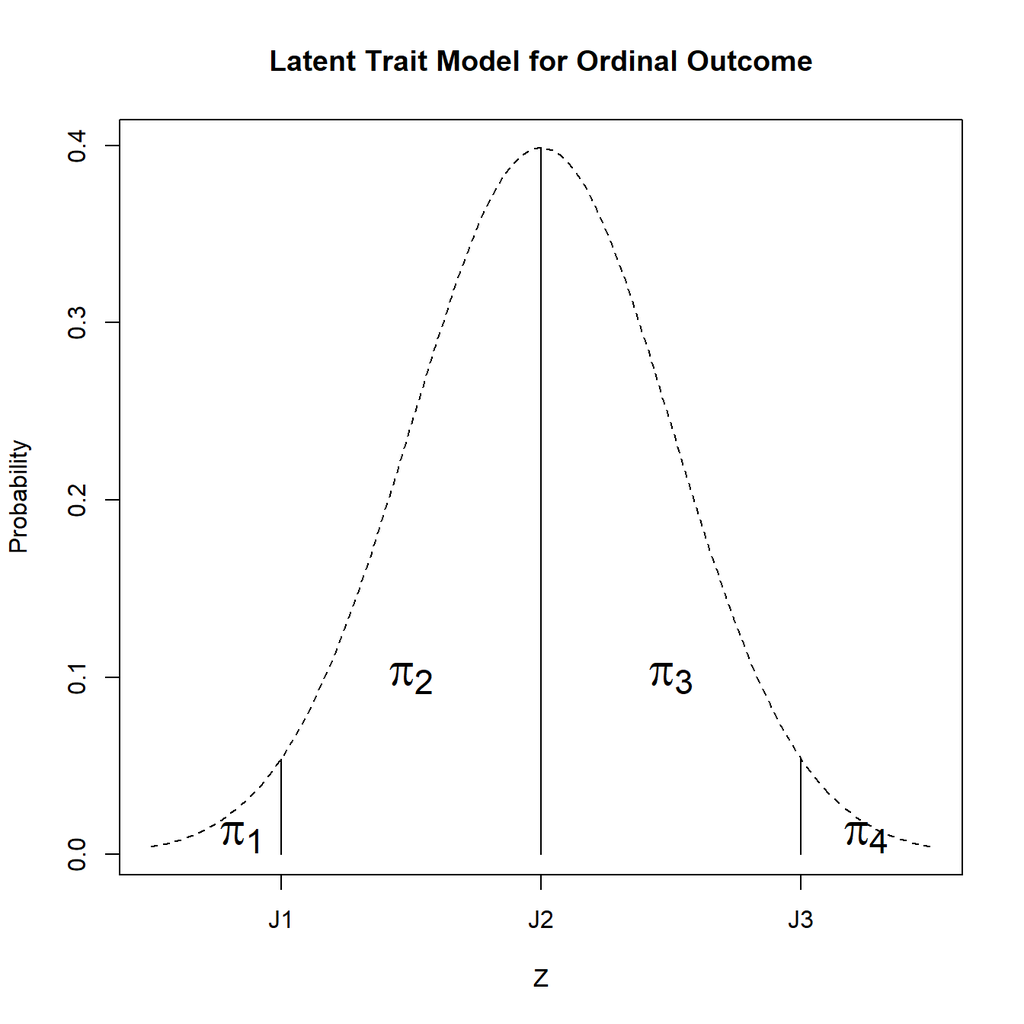

The most common model for an ordinal outcome such as this is the *Proportional Odds Model*. In this model, for each level of *J*, there is an intercept term, $\beta_{0j}$ which depends on the category, *J*. The other explanatory variables *x* do not depend on the category *J*, however. This generates a model of the form:

$$\text {log} \frac{\pi_1+\cdots
+\pi_j}{\pi_{j+1}+\cdots +\pi_j} = \beta_{0j}+x'\beta$$
The base assumption for this model is that each *x* variable affects the probability of J increasing by 1 level in the same way, for all transitions.

We can visualize this as:

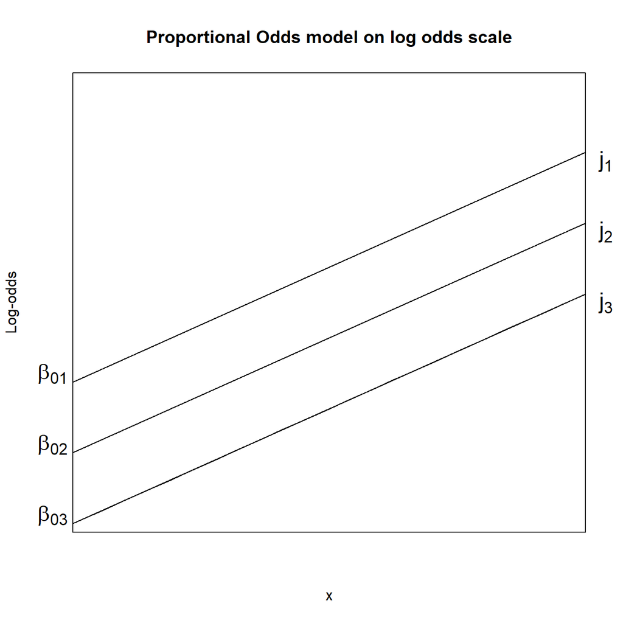

This model is attractive because we have a direct and consistent interpretation of our $\beta$’s in the model. While this is nice, the assumption can be very weak in practice, with the $\beta$’s not being equal between categories. In other words, come covariates may affect the probability of certain transitions more than others.

We can evaluate the assumption generally by fitting a series of binomial logistic regressions and examining the $\beta$’s between them. This can be done by re-coding the outcome from a single ordered outcome to a series of binomial outcomes.

For example:

```r
#General ordinal coding, with 5 being the worst and 1 being the best health
brfss20$generalhealth<-Recode(brfss20$genhlth,
                               recodes="1:2=1;3=2;4:5=3; else=NA",
                               as.factor = T)

brfss20$generalhealth<-relevel(brfss20$generalhealth, ref = "1")

brfss20$healthnum<-car::Recode(brfss20$genhlth,
                                recodes="1:2=1;3=2;4:5=3; else=NA",
                                as.factor = F)

#First we tell R our survey design
options(survey.lonely.psu = "adjust")


library(dplyr)
sub<-brfss20%>%
  select(badhealth,healthnum,generalhealth, mmsaname, bmi,
         agec,race_eth, marst, educ,white, black, hispanic,
         other, smoke, ins, mmsawt, ststr) %>%
  filter( complete.cases(.))

#First we tell R our survey design
options(survey.lonely.psu = "adjust")
des<-svydesign(ids=~1,
               strata=~ststr,
               weights=~mmsawt,
               data =sub )
```

## Ordinal Regression example

To fit an ordinal logit to survey data in R, we use the `svyolr` function in the survey library.

```r
library(gtsummary)

#Here I fit three nested models for the health outcome
fit.solr1<-svyolr(generalhealth~race_eth+educ+agec,
                  design = des)
fit.solr1%>%
  tbl_regression()
```

| **Characteristic** | **log(OR)**<sup>1</sup> | **95% CI**<sup>1</sup> |
| --- | --- | --- |
| race_eth |  |  |
| hispanic | — | — |
| nh black | 0.06 | -0.03, 0.15 |
| nh multirace | -0.01 | -0.17, 0.15 |
| nh other | -0.05 | -0.17, 0.07 |
| nhwhite | -0.42 | -0.49, -0.35 |
| educ |  |  |
| 2hsgrad | — | — |
| 0Prim | 0.81 | 0.65, 1.0 |
| 1somehs | 0.64 | 0.55, 0.74 |
| 3somecol | -0.26 | -0.32, -0.20 |
| 4colgrad | -0.88 | -0.94, -0.83 |
| agec |  |  |
| (0,24] | — | — |
| (24,39] | 0.35 | 0.26, 0.44 |
| (39,59] | 0.74 | 0.66, 0.83 |
| (59,79] | 1.2 | 1.1, 1.3 |
| (79,99] | 1.5 | 1.3, 1.6 |

<sup>*1*</sup> OR = Odds Ratio, CI = Confidence Interval

```r
#Calculate the AIC
```

We also see that as education increases, the odds of reporting poorer health decreases, while for lower levels of education, the odds of having worse health are higher. As age increases, the odds of reporting poorer health increases, compared to those <25 years of age.

Now we can “examine” the proportional odds assumption by fitting logits for each change

```r
ex1<-svyglm(I(healthnum>1)~race_eth+educ+agec,
            design = des,
            family="binomial")
ex2<-svyglm(I(healthnum>2)~race_eth+educ+agec,
            design = des,
            family="binomial")
```

This is **NOT** a statistical test, just a a rough guide. Here, I plot the coefficients of each model. If the proportional odds is correct, and the assumption is ok, then all these should be “approximately” the same values.

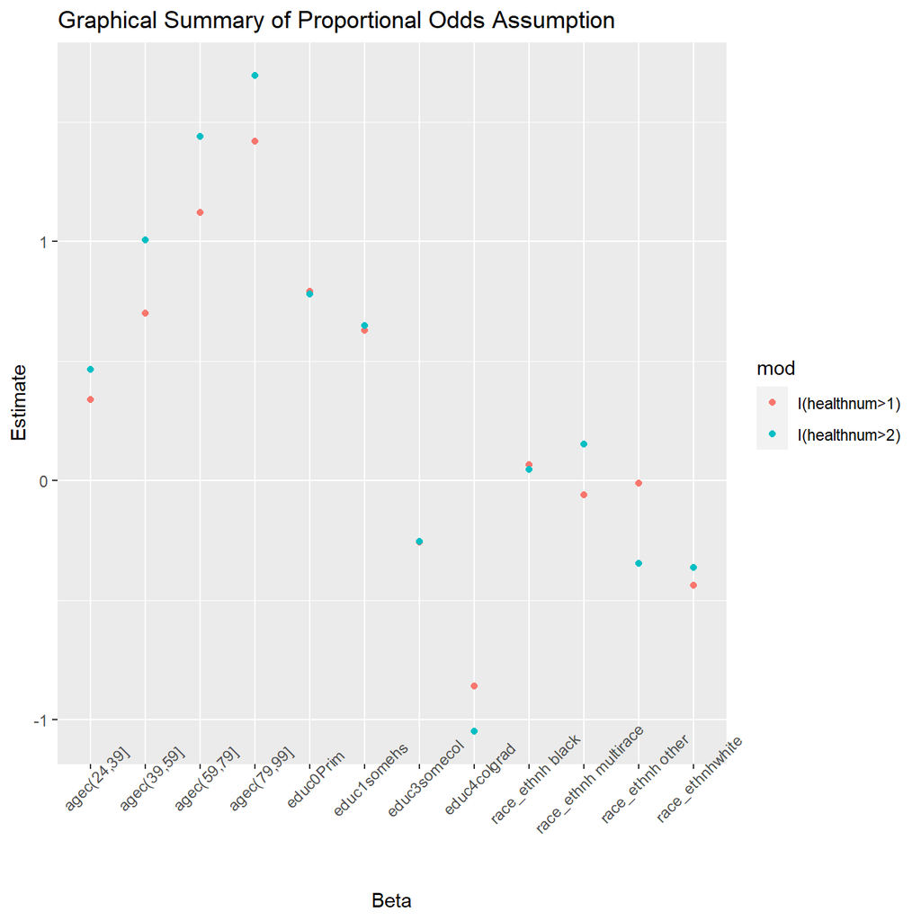

```r
coefs<-data.frame(parms =c( coefficients(ex1)[-1],
                            coefficients(ex2)[-1]),
                  beta = rep(names(coefficients(ex1))[-1], 2 ),
                  mod = c(rep("I(healthnum>1)",12 ),
                          rep("I(healthnum>2)",12 )))

coefs%>%
  ggplot()+
  geom_point(aes(x=beta, y=parms, color=mod))+
  theme(axis.text.x = element_text(angle = 45))+
  labs(title = "Graphical Summary of Proportional Odds Assumption",
       x= "Beta",
       y= "Estimate")
```

```r
#Just print the odds ratios,
round(exp(rbind(coef(ex1)[-1],
                coef(ex2)[-1])),3)
```

```
##      race_ethnh black race_ethnh multirace race_ethnh other race_ethnhwhite
## [1,]            1.069                0.942            0.989           0.646
## [2,]            1.049                1.164            0.707           0.696
##      educ0Prim educ1somehs educ3somecol educ4colgrad agec(24,39] agec(39,59]
## [1,]     2.207       1.873        0.774        0.424       1.404       2.015
## [2,]     2.181       1.915        0.775        0.350       1.591       2.739
##      agec(59,79] agec(79,99]
## [1,]       3.069       4.138
## [2,]       4.225       5.453
```

### Non proportional assumptions

```r
#Proportional odds
fit.vgam<-svy_vglm(as.ordered(generalhealth)~race_eth+educ+agec,
                   design = des,
               family=cumulative(parallel = T,
                                 reverse = T))  #<-parallel = T == proportional odds

m1 <- fit.vgam%>%
  tbl_regression()
```

[output not shown]

[output not shown]

[output not shown]

[output not shown]

[output not shown]

```r
m1
```

| **Characteristic** | **Beta** | **95% CI**<sup>1</sup> | **p-value** |
| --- | --- | --- | --- |
| (Intercept):1 | -0.47 | -0.57, -0.37 | <0.001 |
| (Intercept):2 | -2.2 | -2.3, -2.1 | <0.001 |
| race_ethnh black | 0.06 | -0.03, 0.15 | 0.2 |
| race_ethnh multirace | -0.01 | -0.16, 0.15 | >0.9 |
| race_ethnh other | -0.05 | -0.17, 0.07 | 0.4 |
| race_ethnhwhite | -0.42 | -0.49, -0.35 | <0.001 |
| educ0Prim | 0.81 | 0.65, 1.0 | <0.001 |
| educ1somehs | 0.65 | 0.55, 0.74 | <0.001 |
| educ3somecol | -0.26 | -0.32, -0.20 | <0.001 |
| educ4colgrad | -0.88 | -0.94, -0.83 | <0.001 |
| agec(24,39] | 0.35 | 0.26, 0.44 | <0.001 |
| agec(39,59] | 0.74 | 0.66, 0.83 | <0.001 |
| agec(59,79] | 1.2 | 1.1, 1.3 | <0.001 |
| agec(79,99] | 1.5 | 1.3, 1.6 | <0.001 |

<sup>*1*</sup> CI = Confidence Interval

```r
summary(fit.vgam)
```

```
## svy_vglm.survey.design(as.ordered(generalhealth) ~ race_eth +
##     educ + agec, design = des, family = cumulative(parallel = T,
##     reverse = T))
## Stratified Independent Sampling design (with replacement)
## svydesign(ids = ~1, strata = ~ststr, weights = ~mmsawt, data = sub)
##                            Coef         SE        z         p
## (Intercept):1        -0.4714794  0.0516878  -9.1217 < 2.2e-16
## (Intercept):2        -2.1984394  0.0522345 -42.0879 < 2.2e-16
## race_ethnh black      0.0620980  0.0451471   1.3755    0.1690
## race_ethnh multirace -0.0078767  0.0790714  -0.0996    0.9206
## race_ethnh other     -0.0480145  0.0610162  -0.7869    0.4313
## race_ethnhwhite      -0.4207963  0.0367212 -11.4592 < 2.2e-16
## educ0Prim             0.8065104  0.0799650  10.0858 < 2.2e-16
## educ1somehs           0.6452082  0.0503952  12.8030 < 2.2e-16
## educ3somecol         -0.2585956  0.0289584  -8.9299 < 2.2e-16
## educ4colgrad         -0.8840644  0.0266643 -33.1553 < 2.2e-16
## agec(24,39]           0.3523824  0.0466096   7.5603 4.021e-14
## agec(39,59]           0.7429413  0.0445467  16.6778 < 2.2e-16
## agec(59,79]           1.1725773  0.0440866  26.5971 < 2.2e-16
## agec(79,99]           1.4596478  0.0591237  24.6881 < 2.2e-16
```

```r
#Non-proportional odds
fit.vgam2<-svy_vglm(as.ordered(generalhealth)~race_eth+educ+agec,
                design = des,
                family=cumulative(parallel = F, reverse = T))  #<-parallel = F == Nonproportional odds


m2 <- fit.vgam2%>%
  tbl_regression()
```

[output not shown]

[output not shown]

[output not shown]

[output not shown]

[output not shown]

```r
m2
```

| **Characteristic** | **Beta** | **95% CI**<sup>1</sup> | **p-value** |
| --- | --- | --- | --- |
| (Intercept):1 | -0.45 | -0.56, -0.34 | <0.001 |
| (Intercept):2 | -2.4 | -2.5, -2.2 | <0.001 |
| race_ethnh black:1 | 0.07 | -0.03, 0.16 | 0.2 |
| race_ethnh black:2 | 0.04 | -0.09, 0.17 | 0.5 |
| race_ethnh multirace:1 | -0.06 | -0.22, 0.11 | 0.5 |
| race_ethnh multirace:2 | 0.15 | -0.06, 0.36 | 0.2 |
| race_ethnh other:1 | 0.00 | -0.13, 0.14 | >0.9 |
| race_ethnh other:2 | -0.32 | -0.50, -0.14 | <0.001 |
| race_ethnhwhite:1 | -0.43 | -0.51, -0.36 | <0.001 |
| race_ethnhwhite:2 | -0.36 | -0.46, -0.26 | <0.001 |
| educ0Prim:1 | 0.80 | 0.61, 1.0 | <0.001 |
| educ0Prim:2 | 0.79 | 0.60, 1.0 | <0.001 |
| educ1somehs:1 | 0.63 | 0.51, 0.74 | <0.001 |
| educ1somehs:2 | 0.65 | 0.52, 0.77 | <0.001 |
| educ3somecol:1 | -0.26 | -0.32, -0.20 | <0.001 |
| educ3somecol:2 | -0.25 | -0.33, -0.17 | <0.001 |
| educ4colgrad:1 | -0.86 | -0.91, -0.80 | <0.001 |
| educ4colgrad:2 | -1.0 | -1.1, -1.0 | <0.001 |
| agec(24,39]:1 | 0.34 | 0.25, 0.44 | <0.001 |
| agec(24,39]:2 | 0.46 | 0.30, 0.61 | <0.001 |
| agec(39,59]:1 | 0.71 | 0.61, 0.80 | <0.001 |
| agec(39,59]:2 | 1.0 | 0.84, 1.1 | <0.001 |
| agec(59,79]:1 | 1.1 | 1.0, 1.2 | <0.001 |
| agec(59,79]:2 | 1.4 | 1.3, 1.6 | <0.001 |
| agec(79,99]:1 | 1.4 | 1.3, 1.5 | <0.001 |
| agec(79,99]:2 | 1.7 | 1.5, 1.9 | <0.001 |

<sup>*1*</sup> CI = Confidence Interval

You can calculate an AIC of sorts by hand

```r
-2*fit.vgam$fit@criterion$loglikelihood + 2*length(fit.vgam$coef)
```

```
## [1] 220397332
```

```r
-2*fit.vgam2$fit@criterion$loglikelihood + 2*length(fit.vgam2$coef)
```

```
## [1] 220023482
```

So the non-proportional odds model has a much lower AIC.

## Multinomial Model

We also commonly see a response variable with unordered categories for a response. Such as:

- A person is deciding whether to migrate to a set of possible new labor markets
- A person is deciding which of a set of possible child care arrangement to use
- A person is deciding which of a possible set of means by which to get to work
- The type of contraception a woman chooses

These are example of what generally is called an alternative decision making process.

A distribution commonly used for this type of outcome is the multivariate extension of the binomial distribution, known as the multinomial distribution.

If you have an outcome with *J* *unordered* classes, then $\pi_1$, $\pi_2$, …, $\pi_J$ are the probabilities of observing the *J* classes. Remember, $\sum_J \pi_j = 1$.

If we observe $y_1$ outcomes in the first category and $y_2$ outcomes in the second and so on, the let:

$$\mathbf{y}=\begin{bmatrix}
y_1\\
y_2\\
\vdots \\
y_4
\end{bmatrix}, with \sum_{j=1}^Jy_i = n$$

In this case y follows the multinomial distribution:

$$f(y|n)=\frac{n!}{y_1!y_2!\cdots y_j!}
\pi_1^{y1}\pi_2^{y2}\cdots\pi_J^{yJ}$$

When constructing a regression model for such a distribution, we choose one level of the outcome as the **reference level** and compare the probability of choosing other options to it. For example, if we modeled the probability of choosing option j to option 1 (as the reference level), the we would have the logistic regression model:

$$logit(\pi_{j}) =log \left (
\frac{\pi_j}{\pi_1} \right)=x'_j\beta_j$$

This makes *J-1* equations, again with the reference category estimated by the complementary rule. We then have a total of *J-1* regression equations to interpret, where we compare the odds of being in each of the other *j-1* categories to the reference category. If we want to estimate the probability of being in each particular class of the outcome, for a response with a given set of x values, we can solve the equation for $\pi_j$ as:

$$\pi_j =
\frac{exp(x'_j\beta_j)}{1+\sum_{j=2}^J
exp(x'_j\beta_j)}$$

This is a much more complicated model than the proportional odds model, and we will have many more effects to interpret, owing to the J-1 separate equations we are estimating.

Unfortunately, in R there is no multinomial survey design model, so we have to use VGAM again and feed the function our normalized weights.

Now I fit the model, There is no survey-corrected multinomial model in R, so we use `vglm` and use

```
family =
multinomial
```

.

```r
mfit<-svy_vglm(generalhealth~race_eth+educ+agec,
           family=multinomial(refLevel = 1),
           design = des)
mfit%>%
  tbl_regression()
```

[output not shown]

[output not shown]

[output not shown]

[output not shown]

[output not shown]

| **Characteristic** | **Beta** | **95% CI**<sup>1</sup> | **p-value** |
| --- | --- | --- | --- |
| (Intercept):1 | -0.70 | -0.82, -0.58 | <0.001 |
| (Intercept):2 | -2.0 | -2.1, -1.8 | <0.001 |
| race_ethnh black:1 | 0.06 | -0.05, 0.17 | 0.3 |
| race_ethnh black:2 | 0.08 | -0.06, 0.21 | 0.3 |
| race_ethnh multirace:1 | -0.12 | -0.31, 0.06 | 0.2 |
| race_ethnh multirace:2 | 0.10 | -0.13, 0.32 | 0.4 |
| race_ethnh other:1 | 0.08 | -0.07, 0.23 | 0.3 |
| race_ethnh other:2 | -0.32 | -0.51, -0.13 | <0.001 |
| race_ethnhwhite:1 | -0.40 | -0.49, -0.32 | <0.001 |
| race_ethnhwhite:2 | -0.53 | -0.63, -0.42 | <0.001 |
| educ0Prim:1 | 0.57 | 0.35, 0.80 | <0.001 |
| educ0Prim:2 | 1.1 | 0.88, 1.3 | <0.001 |
| educ1somehs:1 | 0.48 | 0.34, 0.61 | <0.001 |
| educ1somehs:2 | 0.89 | 0.75, 1.0 | <0.001 |
| educ3somecol:1 | -0.22 | -0.29, -0.15 | <0.001 |
| educ3somecol:2 | -0.34 | -0.43, -0.26 | <0.001 |
| educ4colgrad:1 | -0.71 | -0.77, -0.64 | <0.001 |
| educ4colgrad:2 | -1.3 | -1.4, -1.2 | <0.001 |
| agec(24,39]:1 | 0.27 | 0.17, 0.37 | <0.001 |
| agec(24,39]:2 | 0.56 | 0.39, 0.72 | <0.001 |
| agec(39,59]:1 | 0.53 | 0.43, 0.63 | <0.001 |
| agec(39,59]:2 | 1.2 | 1.0, 1.3 | <0.001 |
| agec(59,79]:1 | 0.88 | 0.78, 1.0 | <0.001 |
| agec(59,79]:2 | 1.8 | 1.6, 1.9 | <0.001 |
| agec(79,99]:1 | 1.1 | 1.0, 1.3 | <0.001 |
| agec(79,99]:2 | 2.2 | 2.0, 2.3 | <0.001 |

<sup>*1*</sup> CI = Confidence Interval

Compare all three models with our home-made AIC

```r
-2*fit.vgam$fit@criterion$loglikelihood + 2*length(fit.vgam$coef)
```

```
## [1] 220397332
```

```r
-2*fit.vgam2$fit@criterion$loglikelihood + 2*length(fit.vgam2$coef)
```

```
## [1] 220023482
```

```r
-2*mfit$fit@criterion$loglikelihood + 2*length(mfit$coef)
```

```
## [1] 220010910
```

So in these results, each equation is presented, based off what the transition is. For example. `race_ethnh black:1` corresponds to the odds ratio for nh black respondents having good compared to verygood/excellent health, compared to Hispanics

And the `race_ethnh black:2` odds ratio is the odds ratio for nh black respondents having fair/poor versus verygood/excellent health, compared to Hispanics.

In terms of education, those with primary school and some high school are more likely to report good, compared to excellent/vg health, compared to those with high school, but those with college education are less likely to report good vs excellent/vg health, compared to those with high school.